# Analyzing the Impacts of Gross Domestic Product on Quality of Life

- Introduction
- Data Wrangling
- Exploratory Data Analysis
- Conclusions

## Introduction

In 2005, Dr. Hans Rosling, together with his son and daughter-in-law, founded the [Gapminder Foundation](https://www.gapminder.org) to fight ignorance. The foundation has analyzed and measured ignorance on a wide variety of topics and released not only their findings, but also the underlying data. They also developed and released their [own visualization tool](https://www.gapminder.org/tools-offline/) that allows anybody to create informative charts without the need to program. In 2018 their book 'Factfulness' became a world wide bestseller and features many data visualizations based on the Gapminder dataset.

The [full dataset](https://www.gapminder.org/data/) contains hundreds of different indicators that are searchable through a web interface, allowing *.csv* or *.xlsx* exports of individual indicators. Alternatively, the full dataset is accessible as a github repository. The information in this repository is stored with each indicator in a *.csv* file per the [DDF data model](https://open-numbers.github.io/ddf.html).

For this project, the effect of gross domestic product (GDP) on a country or region's wellbeing will be analyzed using the Gapminder dataset.

First, the development of GDP through the years will be analyzed. What regions or countries have grown the most and how is this growth concentrated? In the next section the following indicators will be used to determine the effect of GDP per capita on quality of life:

- Life expectancy
- Number of children per woman
- Child deaths under 5 years of age
- Percentage of girls completing elementary school
- Percentage of malnutrition in children under 5 yeras of age

Is there a correlation between GDP and these indicators? Is this correlation weaker or stronger depending on region?

Per Gapminder, the GDP data used throughout this analysis is in constant 2010 U.S. dollars, converted (where possible) using the 2010 exchange rate from the local currency to U.S. dollars.

## Data Wrangling

### Python Library Imports

The below codeblock contains all imports used throughout this Notebook.

```python
import pandas as pd
import numpy as np
import matplotlib.pyplot as plt
import seaborn as sns
from ipywidgets import interact, fixed   # to create interactive content
import ipywidgets as widgets
from functools import reduce
from IPython.display import Image
from IPython.core.display import HTML
import sys

#local functions
import print_info as pi # (for comments see: ./print_info.py)

#enable inline plotting in notebook:
%matplotlib inline
```

### Accessing the Gapminder Data

For this analysis, the Gapminder dataset is accessed by cloning the github repository using:

`git clone https://github.com/open-numbers/ddf--gapminder--systema_globalis.git`

As stated in the introduction, the data in the Gapminder dataset (also called *Systema Globalis*), is organized as a loose set of *.csv* files. Each file contains a single indicator with the data stored stored as *key-value* pairs. For example, the GDP information for this analysis is stored in the file *ddf--datapoints--gdppercapita_us_inflation_adjusted--by--geo--time.csv* and its data is stored using the keys *geo* and *time* and value *gdppercapita_us_inflation_adjusted*. Note that per the DDF model this information can also be inferred by the naming convention of the *.csv* file.

Gapminder uses a lower case string as location identifier (e.g. *usa* for United States). This information is stored in the file: *ddf--entities--geo--country.csv*.

The *geo* key can be used in all the individual indicator files to lookup the name of the location, as well as other properties that Gapminder tracks per location.

### General Properties

#### Naming Convention

To use multiple files from the dataset without having to hard code each file's full filename, the following file and path naming convention will be used:

- folder paths always end with '/'
- file names never start with a '/'

#### Setup the file environment

The `dataroot` contains the path name of the folder that contains information pertaining to *all* indicators, such as a list of countries, a .json file describing the dataset and more. `sub` contains the path name relative to the root folder of the folder containing all the indicators in the Gapminder dataset.

```python
dataroot = r'./ddf--gapminder--systema_globalis/'
sub = r'countries-etc-datapoints/'
```

#### Applying Themes

The following code block contains all globally applied themes and font settings.

```python
# apply Seaborn style to plots
sns.set_theme(context = 'notebook')
```

### Loading the CSV Files

In this section all data from the Gapminder *csv* files is loaded into Pandas DataFrames.

#### Independent Variable: GDP per Capita

```python
gdp_per_cap_by_geo = r'ddf--datapoints--gdppercapita_us_inflation_adjusted--by--geo--time.csv'
```

#### Dependent Variables

```python
deaths_under_5 = r'ddf--datapoints--all_causes_deaths_in_children_1_59_months_per_1000_births--by--geo--time.csv'
life_expectancy = r'ddf--datapoints--life_expectancy_years--by--geo--time.csv'
malnutrition = r'ddf--datapoints--malnutrition_weight_for_age_percent_of_children_under_5--by--geo--time.csv'
girls_in_school = r'ddf--datapoints--primary_school_completion_percent_of_girls--by--geo--time.csv'
babies_per_woman = r'ddf--datapoints--children_per_woman_total_fertility--by--geo--time.csv'
```

#### Additional Indicators

We'll use three additional indicators:

- Total GDP
- Population size
- Geographic Entities

The first two indicators are useful when grouping by region. Population size can be used to show a countries influence on aggregate data. Total GDP by country is a useful statistic to compare the economic output of a country. This information could be calculated by using the GDP per capita and multiplying this by population size, but since this indicator is already available in the Gapminder dataset, it easier to use it direcly.

The *Geographic Entities* file contains the official names of all the countries in the dataset as well as additional information regarding region and income groupings.

```python
population_size = r'ddf--datapoints--population_total--by--geo--time.csv'
total_gdp_by_geo = r'ddf--datapoints--total_gdp_us_inflation_adjusted--by--geo--time.csv'
geo = r'ddf--entities--geo--country.csv'
```

### Creating the Individual Dataframes

In this chapter the necessary DataFrames will be put together through a series of steps. First, each *csv* file will be loaded into each own DataFrame. Next, the data will be inspected, cleaned where necessary and finally joined together into a single DataFrame.

#### Load *csv* Files

```python
df_gdp_per_cap = pd.read_csv(dataroot+sub+gdp_per_cap_by_geo)
df_total_gdp = pd.read_csv(dataroot+sub+total_gdp_by_geo)
df_deaths_under_5 = pd.read_csv(dataroot+sub+deaths_under_5)
df_life_expectancy = pd.read_csv(dataroot+sub+life_expectancy)
df_malnutrition = pd.read_csv(dataroot+sub+malnutrition)
df_girls_in_school = pd.read_csv(dataroot+sub+girls_in_school)
df_babies_per_woman = pd.read_csv(dataroot+sub+babies_per_woman)

df_population_size = pd.read_csv(dataroot+sub+population_size)
df_geo = pd.read_csv(dataroot+geo)
```

A dicitionary consisting of a DataFrame description and a DataFrame variable name (*key-value pair*) will be setup. This allows the easy printing of a description when performing analysis on each element using a loop.

```python
dict_of_df = {'GDP per Capita': df_gdp_per_cap,
              'Total GDP': df_total_gdp,
              'Deaths under 5': df_deaths_under_5,
              'Life Expectancy': df_life_expectancy,
              'Malnutrition': df_malnutrition,
              'Girls in School': df_girls_in_school,
              'Babies per Woman': df_babies_per_woman,
              'Population Size': df_population_size,
              'geo': df_geo}
```

#### Explore the Data

Since all indicators in the Gapminder dataset are stored in the same DDF format, the expectation is to find relatively clean data with, for example, no duplicate keys, or missing values. A few some small functions will be created to loop through the list of dataframes and check for these conditions.

```python
def show_duplicates(dict_of_df):
    """Prints the sum total of duplicated rows for all dataframes in a the supplied dictionary."""
    print("****************************************")
    for name, df in dict_of_df.items():
        print(name," has ",df.duplicated().sum()," duplicated row(s)")
    print("****************************************")

def show_nulls(dict_of_df):
    """Prints the count of null (NaN) values for each column in each dataframe in the supplied dict"""
    print("****************************************")
    for name, df in dict_of_df.items():
        if df.isnull().sum().sum() != 0:
            print(name," has the following number of null values: ")
            print(df.isnull().sum())
        else:
            print(name, "has no null values")
    print("****************************************")

def print_head(dict_of_df,number_of_rows):
    """prints the output of head() for each dataframe in the supplied dict.
    The number of rows is set by the 2nd input 'number_of_rows'
    """
    print("****************************************")
    for name, df in dict_of_df.items():
        print(name)
        display(df.head(number_of_rows))
    print("****************************************")
```

The result of the functions above is shown below:

```python
print(" - DUPLICATES -")
show_duplicates(dict_of_df)
print(" - NULL VALUES -")
show_nulls(dict_of_df)
print(" - HEAD")
print_head(dict_of_df,2)
```

```
 - DUPLICATES -
GDP per Capita  has  0  duplicated row(s)
Total GDP  has  0  duplicated row(s)
Deaths under 5  has  0  duplicated row(s)
Life Expectancy  has  0  duplicated row(s)
Malnutrition  has  0  duplicated row(s)
Girls in School  has  0  duplicated row(s)
Babies per Woman  has  0  duplicated row(s)
Population Size  has  0  duplicated row(s)
geo  has  0  duplicated row(s)
 - NULL VALUES -
GDP per Capita has no null values
Total GDP has no null values
Deaths under 5 has no null values
Life Expectancy has no null values
Malnutrition has no null values
Girls in School has no null values
Babies per Woman has no null values
Population Size has no null values
geo  has the following number of null values:
country                     0
g77_and_oecd_countries     14
income_3groups             55
income_groups              55
is--country                 0
iso3166_1_alpha2           27
iso3166_1_alpha3           26
iso3166_1_numeric          26
iso3166_2                 272
landlocked                 18
latitude                   32
longitude                  32
main_religion_2008         57
name                        0
un_sdg_ldc                 24
un_sdg_region              25
un_state                    0
unicef_region              78
unicode_region_subtag      25
world_4region               2
world_6region              13
dtype: int64
 - HEAD
GDP per Capita
```

|  | geo | time | gdppercapita_us_inflation_adjusted |
| --- | --- | --- | --- |
| 0 | abw | 1986 | 15669.61604 |
| 1 | abw | 1987 | 18427.61153 |

```
Total GDP
```

|  | geo | time | total_gdp_us_inflation_adjusted |
| --- | --- | --- | --- |
| 0 | abw | 1986 | 9.816074e+08 |
| 1 | abw | 1987 | 1.139435e+09 |

```
Deaths under 5
```

|  | geo | time | all_causes_deaths_in_children_1_59_months_per_1000_births |
| --- | --- | --- | --- |
| 0 | afg | 2008 | 195.2 |
| 1 | ago | 2008 | 166.8 |

```
Life Expectancy
```

|  | geo | time | life_expectancy_years |
| --- | --- | --- | --- |
| 0 | afg | 1800 | 28.21 |
| 1 | afg | 1801 | 28.20 |

```
Malnutrition
```

|  | geo | time | malnutrition_weight_for_age_percent_of_children_under_5 |
| --- | --- | --- | --- |
| 0 | afg | 1997 | 44.9 |
| 1 | afg | 2004 | 32.9 |

```
Girls in School
```

|  | geo | time | primary_school_completion_percent_of_girls |
| --- | --- | --- | --- |
| 0 | abw | 1999 | 102.50000 |
| 1 | abw | 2000 | 97.12557 |

```
Babies per Woman
```

|  | geo | time | children_per_woman_total_fertility |
| --- | --- | --- | --- |
| 0 | abw | 1800 | 5.64 |
| 1 | abw | 1801 | 5.64 |

```
Population Size
```

|  | geo | time | population_total |
| --- | --- | --- | --- |
| 0 | afg | 1800 | 3280000 |
| 1 | afg | 1801 | 3280000 |

```
geo
```

|  | country | g77_and_oecd_countries | income_3groups | income_groups | is--country | iso3166_1_alpha2 | iso3166_1_alpha3 | iso3166_1_numeric | iso3166_2 | landlocked | ... | longitude | main_religion_2008 | name | un_sdg_ldc | un_sdg_region | un_state | unicef_region | unicode_region_subtag | world_4region | world_6region |
| --- | --- | --- | --- | --- | --- | --- | --- | --- | --- | --- | --- | --- | --- | --- | --- | --- | --- | --- | --- | --- | --- |
| 0 | abkh | others | NaN | NaN | True | NaN | NaN | NaN | NaN | NaN | ... | NaN | NaN | Abkhazia | NaN | NaN | False | NaN | NaN | europe | europe_central_asia |
| 1 | abw | others | high_income | high_income | True | AW | ABW | 533.0 | NaN | coastline | ... | -69.96667 | christian | Aruba | un_not_least_developed | un_latin_america_and_the_caribbean | False | NaN | AW | americas | america |

2 rows × 21 columns

Both the pandas `head()` and `info()` methods confirm the data is indeed structured per the *DDF* format, with a string as geographical indicator, and time in years stored as an integer. The values are stored as 64bit floats. The structure of the *geo* file is a little different. It contains multiple values for each country and for this file, the country identifier is not named `geo`, but `country`. We'll take a closer look at this dataframe below.

#### Explore the *geo* Data

This section take a look data structure of the *geo* dataframe, followed by some data clean-up.

```python
pi.print_info(df_geo);
```

| column | count | value_type | dtype |
| --- | --- | --- | --- |
| country | 273 | non-null | object |
| g77_and_oecd_countries | 259 | non-null | object |
| income_3groups | 218 | non-null | object |
| income_groups | 218 | non-null | object |
| is--country | 273 | non-null | bool |
| iso3166_1_alpha2 | 246 | non-null | object |
| iso3166_1_alpha3 | 247 | non-null | object |
| iso3166_1_numeric | 247 | non-null | float64 |
| iso3166_2 | 1 | non-null | object |
| landlocked | 255 | non-null | object |
| latitude | 241 | non-null | float64 |
| longitude | 241 | non-null | float64 |
| main_religion_2008 | 216 | non-null | object |
| name | 273 | non-null | object |
| un_sdg_ldc | 249 | non-null | object |
| un_sdg_region | 248 | non-null | object |
| un_state | 273 | non-null | bool |
| unicef_region | 195 | non-null | object |
| unicode_region_subtag | 248 | non-null | object |
| world_4region | 271 | non-null | object |
| world_6region | 260 | non-null | object |

```
RangeIndex: 273 entries, 0 to 272
dtypes: bool(2), float64(3), object(16)
```

The `info()` method shows 273 countries listed, but not all columns in the DataFrame contain data for these 273 countries (as confirmed by the check for null values above). Of special interest here are the regional groupings, *world_4region* and *world_6region*:

```python
print(df_geo.world_4region.unique())
print(df_geo.world_6region.unique())
```

```
['europe' 'americas' 'asia' 'africa' nan]
['europe_central_asia' 'america' 'south_asia' 'sub_saharan_africa'
 'middle_east_north_africa' 'east_asia_pacific' nan]
```

[output not shown]

The 6-region column has 13 entries missing, whereas the 4-region column only has 2 entries missing:

```python
no_region_idx = df_geo[df_geo.world_4region.isnull()].index
df_no_region = df_geo.iloc[no_region_idx][['country','name','un_sdg_region']]
```

```python
no_region_idx = df_geo[df_geo.world_6region.isnull()].index
df_no_region = df_geo.iloc[no_region_idx][['country','name','un_sdg_region']]
```

Using the information from the *un_sdg_region* column, most territories from the *world_6* grouping can be reassigned. This column uses the regional breakdown as used by the United Nations for their Sustainable Development Goals (SDGs)

```python
region_map = {'un_latin_america_and_the_caribbean':'america',
             'un_sub_saharan_africa': 'sub_saharan_africa',
             'un_australia_and_new_zealand':'east_asia_pacific',
             'un_oceania_exc_australia_and_new_zealand':'east_asia_pacific'}
```

```python
# step 1, set values in world_6region equal to un_sdg_region
# step 2, use .replace to replace values using above dictionary
# please note: using 'in_place = True' does not update values

#get ID's
un_regions = df_geo['un_sdg_region'].iloc[no_region_idx]

df_geo['world_6region'].iloc[no_region_idx] = un_regions

A = df_geo['world_6region'].iloc[no_region_idx].replace(to_replace = region_map, value = None)

df_geo['world_6region'].iloc[no_region_idx] = A
```

Gaza and the West Bank wil be set to the *world_6region* value used for Israel. For United Korea either of the Koreas' value can be used.

```python
df_geo[['name','world_6region']].query('name == "Israel" or name == "South Korea"')
```

|  | name | world_6region |
| --- | --- | --- |
| 118 | Israel | middle_east_north_africa |
| 130 | South Korea | east_asia_pacific |

```python
# 'world_6region is last column (-1)'
df_geo.iloc[[197,198],-1] = 'middle_east_north_africa'
df_geo.iloc[131,-1] = 'east_asia_pacific'
```

```python
display(df_geo.iloc[no_region_idx][['name','un_sdg_region','world_4region','world_6region']])
```

|  | name | un_sdg_region | world_4region | world_6region |
| --- | --- | --- | --- | --- |
| 14 | Antarctica | NaN | europe | NaN |
| 32 | Bouvet Island | un_latin_america_and_the_caribbean | africa | america |
| 81 | French Southern and Antarctic Lands | NaN | NaN | NaN |
| 82 | Clipperton | NaN | NaN | NaN |
| 104 | Heard and McDonald Islands | un_australia_and_new_zealand | asia | east_asia_pacific |
| 113 | British Indian Ocean Territory | un_sub_saharan_africa | asia | sub_saharan_africa |
| 131 | United Korea (former) | NaN | asia | east_asia_pacific |
| 146 | St. Martin (French part) | un_latin_america_and_the_caribbean | americas | america |
| 197 | Gaza Strip | NaN | asia | middle_east_north_africa |
| 198 | West Bank | NaN | asia | middle_east_north_africa |
| 210 | South Georgia and the South Sandwich Islands | un_latin_america_and_the_caribbean | americas | america |
| 232 | Sint Maarten (Dutch part) | un_latin_america_and_the_caribbean | americas | america |
| 255 | US Minor Outlying Islands | un_oceania_exc_australia_and_new_zealand | americas | east_asia_pacific |

The remaining countries / regions are small enough to have no noticeable impact when grouping by region.

Columns that are of no interest are dropped from the *geo* DataFrame. The only columns of interest for analyzing global and geographical trends related to GDP are *country*, *income_groups*, *world_4region* and *world_6region* columns:

```python
df_geo = df_geo[['country','name','income_groups','world_4region','world_6region']]
df_geo = df_geo.dropna(subset = ['world_6region','world_4region'])
```

To make it easier later on to plot or display the data by region, the *geo* is merged with the files from Gapminder files that describe the regions:

```python
regions6 = r'ddf--entities--geo--world_6region.csv'
regions4 = r'ddf--entities--geo--world_4region.csv'

# load files and drop columns
df_regions6 = pd.read_csv(dataroot+regions6)
df_regions4 = pd.read_csv(dataroot+regions4)
df_regions6 = df_regions6.drop(columns = ['is--world_6region','name_long','name_short','rank','shape_lores_svg'])

df_regions4 = df_regions4.drop(columns = ['is--world_4region','name_long','name_short','rank','shape_lores_svg',
                                         'color','description','latitude','longitude'])

# rename the regions' name columns, so that it does not conflict with the name column in the geo set:
df_regions6 = df_regions6.rename(columns={'name':'geo6_name'})
df_regions4 = df_regions4.rename(columns={'name':'geo4_name'})

# join the data
df_geo = df_geo.merge(df_regions6, how = 'left',on = 'world_6region')
df_geo = df_geo.merge(df_regions4, how = 'left',on = 'world_4region')

df_geo.head()
```

|  | country | name | income_groups | world_4region | world_6region | geo6_name | geo4_name |
| --- | --- | --- | --- | --- | --- | --- | --- |
| 0 | abkh | Abkhazia | NaN | europe | europe_central_asia | Europe & Central Asia | Europe |
| 1 | abw | Aruba | high_income | americas | america | America | The Americas |
| 2 | afg | Afghanistan | low_income | asia | south_asia | South Asia | Asia |
| 3 | ago | Angola | lower_middle_income | africa | sub_saharan_africa | Sub-Saharan Africa | Africa |
| 4 | aia | Anguilla | NaN | americas | america | America | The Americas |

### Creating a DataFrame Containing All Indicators

To be able to analyze the influence of GDP on the selected indicators and be able to select and group by country or region, the GDP info needs to be joined with the geo information as well as the individual indicator dataframes.

#### Joining (merging) GDP Data With Indicator Data

The first step is to join the independent variable, GDP, with the selected dependent variables (indicators). Note that from the DDF file naming convention, one can see that all indicators chosen use *geo* and *time* as key. This means the data can be combined using Python's `reduce()` function together with a list comprehension as shown [here](https://stackoverflow.com/questions/44327999/python-pandas-merge-multiple-dataframes).

Joning of the *geo* data will be performed in later step, since this file uses a different key.

```python
list_of_df = list(dict_of_df.values())
df_all_indicators = reduce(lambda left,right: pd.merge(left,
                                                       right,
                                                       on = ['geo','time'],
                                                       how = 'outer'), list_of_df[:-1])
```

```python
pi.print_info(df_all_indicators);
```

| column | count | value_type | dtype |
| --- | --- | --- | --- |
| geo | 64227 | non-null | object |
| time | 64227 | non-null | int64 |
| gdppercapita_us_inflation_adjusted | 9427 | non-null | float64 |
| total_gdp_us_inflation_adjusted | 9430 | non-null | float64 |
| all_causes_deaths_in_children_1_59_months_per_1000_births | 178 | non-null | float64 |
| life_expectancy_years | 56130 | non-null | float64 |
| malnutrition_weight_for_age_percent_of_children_under_5 | 895 | non-null | float64 |
| primary_school_completion_percent_of_girls | 4348 | non-null | float64 |
| children_per_woman_total_fertility | 60715 | non-null | float64 |
| population_total | 59297 | non-null | float64 |

```
Int64Index: 64227 entries, 0 to 64226
dtypes: float64(8), int64(1), object(1)
```

Notice that all indicators are joined together using an outer join: this is because not every entry will be available for each indicator. An inner join would only return rows if all indicators would have a value for a certain key.

#### Joining the Geographical Data

To join the geographical data from the *geo* dataframe the field (columns) to join first need to be identified. For the *geo* dataframe, `country` as used as country identifier instead of `geo`. This means that join to sets together, the columns need to be explicitly called out the `merge()` command.

```python
df = df_all_indicators.merge(df_geo, how = 'left', left_on = 'geo', right_on = 'country')
```

```python
pi.print_info(df);
```

| column | count | value_type | dtype |
| --- | --- | --- | --- |
| geo | 64227 | non-null | object |
| time | 64227 | non-null | int64 |
| gdppercapita_us_inflation_adjusted | 9427 | non-null | float64 |
| total_gdp_us_inflation_adjusted | 9430 | non-null | float64 |
| all_causes_deaths_in_children_1_59_months_per_1000_births | 178 | non-null | float64 |
| life_expectancy_years | 56130 | non-null | float64 |
| malnutrition_weight_for_age_percent_of_children_under_5 | 895 | non-null | float64 |
| primary_school_completion_percent_of_girls | 4348 | non-null | float64 |
| children_per_woman_total_fertility | 60715 | non-null | float64 |
| population_total | 59297 | non-null | float64 |
| country | 64227 | non-null | object |
| name | 64227 | non-null | object |
| income_groups | 61819 | non-null | object |
| world_4region | 64227 | non-null | object |
| world_6region | 64227 | non-null | object |
| geo6_name | 64227 | non-null | object |
| geo4_name | 64227 | non-null | object |

```
Int64Index: 64227 entries, 0 to 64226
dtypes: float64(8), int64(1), object(8)
```

#### Cleaning the Merged DataFrame

Shortening the column names makes the dataframe easier to read. Finally, all rows for which we have no GDP information can be dropped.

```python
df = df.rename(columns = {'gdppercapita_us_inflation_adjusted': 'GDP_per_cap',
                          'total_gdp_us_inflation_adjusted': 'total_GDP',
                     'all_causes_deaths_in_children_1_59_months_per_1000_births': 'child_deaths',
                    'life_expectancy_years': 'life_expectancy',
                    'malnutrition_weight_for_age_percent_of_children_under_5': 'child_malnutrition',
                    'primary_school_completion_percent_of_girls':'girl_school_completion',
                    'children_per_woman_total_fertility': 'children_per_woman',
                    'population_total': 'population' })
```

```python
# number of rows with no GDP data
len(df.query('GDP_per_cap.isnull()', engine = 'python').index)
```

```
54800
```

```python
df.dropna(subset = ['GDP_per_cap'],inplace = True)
```

To easier display and interprete the information it is best to avoid displaying large values. Therefore two additional columns are added to the dataframe. One for *GDP per capita in thousands of dollars* and one for *Total GDP in trillions of dollars*.

```python
df['GDP_per_cap_in_k'] = df.GDP_per_cap/1_000 #convert in thousands of dollars
df['total_GDP_in_T'] = df.total_GDP/1_000_000_000_000 #convert in trillions of dollars
```

## Exploratory Data Analysis

This chapter will analyze the Gapminder data with the cleaned and merged Dataframe (*df*). Plots and tables will be generated to support answering the questions posed in the Introduction. This chapters starts with analazing GDP over time and the moves on to the indicators.

### GDP over Time

To analyze the development of GDP over time, the data needs to be manipulated into a different format. To plot and calculate aggregate data by region, the data needs to be rearranged so that the index is time and each column represents a world region. This can be done with pandas' `pivot_table()` command.

After this transformation is done, GDP and GDP per capital over time will be looked at, followed by an analysis of GDP per capita per region. For this, Gapminder's 6-region breakdown is used, however, the code is setup to be switched to use a breakdown by 4-region as well.

```python
df_gdp_per_cap_by_region = df.pivot_table(index='time',
                                   columns='geo6_name',
                                   values='GDP_per_cap_in_k',
                                   aggfunc={'GDP_per_cap_in_k': np.mean}) #note: default aggregation method is mean

df_total_gdp_by_region = df.pivot_table(index='time',
                                   columns='geo6_name',
                                   values='total_GDP_in_T',
                                   aggfunc={'total_GDP_in_T': np.sum}) #note: default aggregation method is mean
```

#### Global Development of GDP

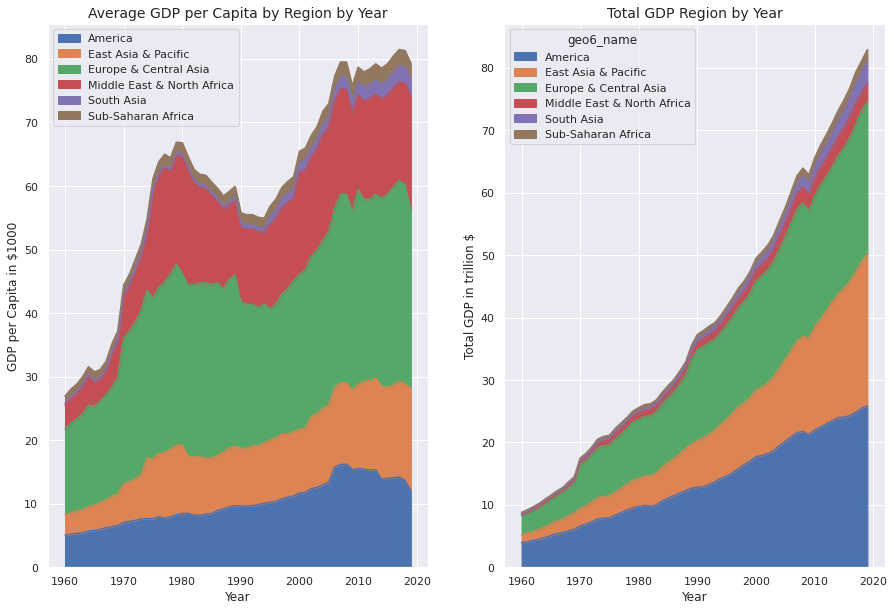

```python
fig, (ax1, ax2)= plt.subplots(1,2)
df_gdp_per_cap_by_region.plot(kind='area',
                              stacked=True,
                              figsize = (15,10),
                              ax = ax1,
                              xlabel = 'Year',
                              ylabel = 'GDP per Capita in \\$1000');

ax1.legend(loc = 'upper left')
#plt.rc('font',size = 12)
ax1.set_title('Average GDP per Capita by Region by Year',fontsize=14)

df_total_gdp_by_region.plot(kind='area',
                            stacked=True,
                            #figsize = (10,7),
                            ax = ax2,
                            xlabel = 'Year',
                            ylabel = 'Total GDP in trillion \\$');

ax2.set_title('Total GDP Region by Year',fontsize=14);
```

The above area plots show large trends quite well, but make individual trends difficult to spot. In the next section, GDP is broken down by region.

#### GDP Development by Region

To efficiently analyze GDP per capita per region, this section will create a subplot of GPD per capita over time using the mean and median values per region.

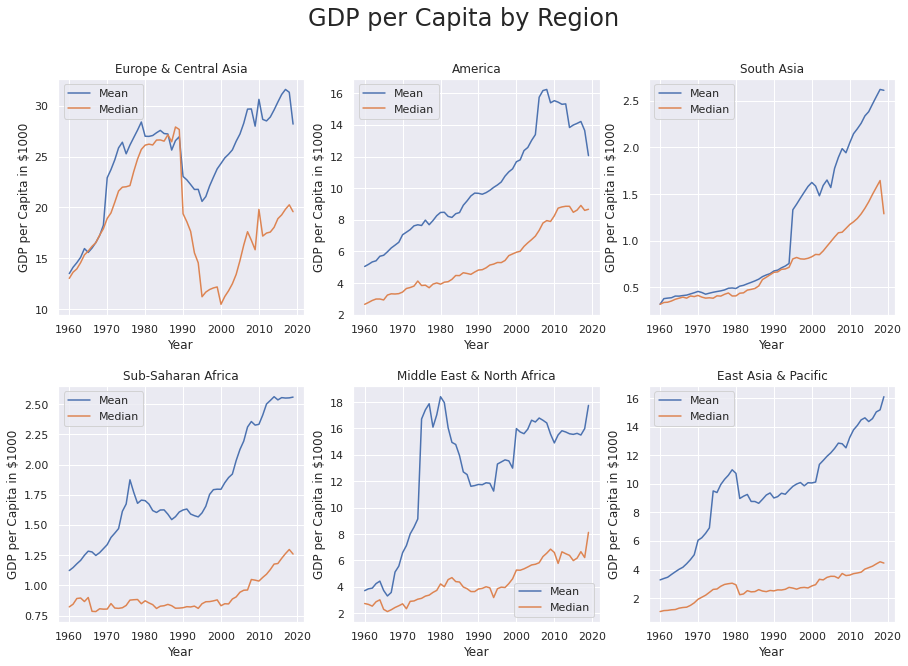

```python
fig, axs = plt.subplots(2,3,
                       figsize=(15,10))
fig.subplots_adjust(hspace= 0.3)
fig.suptitle('GDP per Capita by Region',fontsize = 24)
#note that axs is NxM dimensional array (verifiable with axs.shape),
#therefore, in order to loop over the axs, we need to flatten it.
# see for example:
#https://rayheberer.medium.com/generating-matplotlib-subplots-programmatically-cc234629b648

axs = axs.ravel()

#get list of regions:
regions = df_geo.geo6_name.unique()


#note the parentheses around the full expression, this is so we can use line breaks without using '\'
for i in range(0,len(axs)):
    region = regions[i]
    axs[i] = (df[['time','GDP_per_cap_in_k','geo6_name']]
                .query(f'geo6_name == "{region}"')
                .groupby(['time'])
                .mean()
                .plot(y ='GDP_per_cap_in_k',
                      ax = axs[i],
                      label = 'Mean'));

    axs[i] = (df[['time','GDP_per_cap_in_k','geo6_name']]
                .query(f'geo6_name == "{region}"')
                .groupby(['time'])
                .median()
                .plot(y ='GDP_per_cap_in_k',
                      ax = axs[i],
                      label = 'Median'));

    axs[i].set(title = region, xlabel = 'Year', ylabel = 'GDP per Capita in \\$1000')
```

The above plots show that certain regions have been affected differently by global econmic crises. During the eighties, there is a decrease in average GDP per capita for Europe & Central Asia, Sub Saharan Africa, Middle East & North Africa and East Asia. America and South Asia seem not affected. The housing crisis of 2009 has a profound impact on America but is less pronounced in Europe & Central Asia and the Middle East & Norht Africa.

These figures also show the median GDP per Capita. For all regions, there is a widening gap between the mean and the median, indicating that GDP is not evenly distributed (positively skewed) between all the countries that make up a region. In the next section, we will take a closer look at this.

```python
# calc mean and median for first and last year per region
A = df.query('world_6region =="america" and time == 1960').GDP_per_cap_in_k.describe().to_frame()
A.rename(columns = {'GDP_per_cap_in_k':'1960'}, inplace=True )
A[2019] = df.query('world_6region =="america" and time == 2019').GDP_per_cap_in_k.describe().to_frame()
```

```python
A
```

|  | 1960 | 2019 |
| --- | --- | --- |
| count | 27.000000 | 34.000000 |
| mean | 5.052475 | 12.061819 |
| std | 6.432766 | 12.344452 |
| min | 0.993247 | 0.714483 |
| 25% | 1.498190 | 4.924508 |
| 50% | 2.659525 | 8.667575 |
| 75% | 4.740680 | 14.967915 |
| max | 27.838393 | 55.670236 |

In order to plot the top *x* number of countries per region, we need to verify that the this number *x* does not exceed the total number of countries in a region. Using `groupby()` and `nunique()` we can see how many countries are grouped in each region:

```python
# check for the number of countries per region over all years:
display(df.groupby('world_6region').name.nunique().to_frame())

# check for the minimum number of countries per region by year:
df_n_of_countries = df.groupby(['world_6region','time'], as_index=False).name.nunique()

# get index ID's of minimum count of countries per region:
ids = df_n_of_countries.groupby('world_6region').name.idxmin()

# show table of region, year and mininum number of countries:
display(df_n_of_countries.loc[ids])
```

| world_6region | name |
| --- | --- |
| america | 41 |
| east_asia_pacific | 34 |
| europe_central_asia | 57 |
| middle_east_north_africa | 19 |
| south_asia | 8 |
| sub_saharan_africa | 47 |

|  | world_6region | time | name |
| --- | --- | --- | --- |
| 0 | america | 1960 | 27 |
| 60 | east_asia_pacific | 1960 | 12 |
| 120 | europe_central_asia | 1960 | 15 |
| 180 | middle_east_north_africa | 1960 | 4 |
| 240 | south_asia | 1960 | 4 |
| 300 | sub_saharan_africa | 1960 | 27 |

The above tables show that the number of countries in a region varies per year, with the minimum number of countries occuring in 1960. For this year, plotting a top 10 list would thow an error if not properly handled. The below function handles this by checking if the number of countries received is smaller than the top x it wants to plot.

```python
def plot_top_gdp(year, headsize):
    #setup figure and axes
    fig, axs = plt.subplots(2,3,
                           figsize=(20,15))

    fig.subplots_adjust(hspace = 0.5)

    fig.suptitle(f'Top {headsize} Countries by Total GDP in {year}\n (where available)',
                fontsize = 24)

    #flatten axes so we can iterate
    axs = axs.ravel()

    xcoord = range(headsize)

    for i, ax in enumerate(axs):
        df_GDP_by_region_and_year = (df[['time','name','geo6_name','total_GDP']]
             .query(f'time == {year} and geo6_name == "{regions[i]}"')
             .sort_values(by = 'total_GDP', ascending = False))

        # add column expressing GDP as percentage
        df_GDP_by_region_and_year['total_GDP_perc'] = (100
                                                  * df_GDP_by_region_and_year.total_GDP
                                                  / df_GDP_by_region_and_year.total_GDP.sum())

        # extract plot data
        total_perc = df_GDP_by_region_and_year['total_GDP_perc'].head(headsize).sum()

        xlabels = df_GDP_by_region_and_year.name.head(headsize)
        height = df_GDP_by_region_and_year.total_GDP_perc.head(headsize)

        # check for size mismatch. This happens if the number of
        # top countries selected is larger than the number of countries
        # available in a region for a particular year
        if len(xcoord) > len(height):
            xval = range(len(height))
            topsize = len(height)
        else:
            xval = xcoord
            topsize = headsize

        ax.bar(xval, height)
        ax.text(max(xval),
                    max(height),
                    f'Top {topsize} represents \n {total_perc:.0f}% of regional GDP',
                    ha = 'right',
                    va = 'top',
                    bbox = dict(boxstyle = "square"))
        #note: hidden ticks will cause the first entry of the labels
        # to be skipped when using set_xticklabels without also
        # using set_xticks
        ax.set_xticks(xval)
        ax.set_xticklabels(xlabels, rotation = 45, ha = "right")
        ax.set(title = f'{regions[i]}')
        ax.title.set_size(18)
        ax.set_xlabel('Country', fontsize = 14)
        ax.set_ylabel('% of Regional Total GDP', fontsize = 14)
        #plot each bar's value as well as text
        max_height = max(height)
        for xpos, ypos in enumerate(height):
            ax.text(xpos,
                     ypos + 0.01*max_height, #add 1% extra height for better spacing
                     f'{ypos:.0f}') # format percentage
```

```python
interact(plot_top_gdp,
         year = widgets.IntSlider(min = 1960, max = 2019, step = 1,value = 1960, description = 'Year'),
         headsize = widgets.IntSlider(min = 3, max = 10, step = 1,value = 8, description = 'X in Top X'));
```

Although the rankings change through the years, the overal distribution for all regions is very skewed with most GDP concentrated in only a handful of countries.

The most extreme being America, where the United States is responsible for between 70% and 80% of the region's total GDP. The most evenly distributed region is Europe and Central Asia, although even in this region, the top 10 countries in 2019 still account for 77% of total GDP.

### How is Quality of Life Related to GDP per Capita

To determine how the selected indicators are related to GDP, a framework has to be setup to create a scatterplot. A function that can be reused to plot each indicator will be used in conjunction with an *ipywidget* to control the year variable. This enables quickly looking up the relation between an indicator and GDP for any given year. Another function was written to provide a top and bottom list of performers. This enabels a quick overview for the best and worst performing countries for the selected year. This function also displays the output of the built-in Pandas `describe()` method.

To standardize plotting, a palette dictionary is created to fix the assigned color per region, this avoids changing colors when using interactive plots.

Each section starts with calling the *ipywidget* to create an interactive scatterplot, followed by the second *ipywidget* displaying the output of the statistics function. At the end of each section the results will be discussed.

#### Defining support functions

```python
# setting up a color palette, the colors are chosen arbitrarily
keys = df['geo4_name'].unique()
colors = ['royalblue', 'darkviolet', 'crimson','green']
palette_4region = dict(zip(keys,colors))

keys = df['geo6_name'].unique()
colors = ['royalblue', 'darkviolet', 'crimson','green', 'darkorange','slategray']
palette_6region = dict(zip(keys,colors))
```

```python
def filter_data(df,year,indicator):
    """Simple function that filters a dataframe based on year and indicator"""
    data = df.query(f'time == {year}').dropna(subset=[indicator])
    return data
```

```python
def splot(dframe, year, indicator, ind_label,
          region, logx, logy, xrange = (), yrange = ()):
    """
    Function to plot a Seaborn scatter plot using:
    a dataframe, year, indicator (= variable to be plotted),
    an indicator label (= name to use for variable),
    and inputs to set region (4 or 6 world regions) and
    axes (scale and ranges)
    """

    # filter data based on year and indicator (inputs
    # of the interact widgets)
    data = filter_data(dframe,year,indicator)

    # assign variables based on selected region grouping:
    # please note: number of regions that have data available
    # for the selected combination of year and indicator
    # can vary, cannot hard code to 6 or 4.

    palette_region = {}
    if region == 'geo6_name':
        n_of_legend_entries = data.geo6_name.nunique()
        palette_region = palette_6region
    else:
        n_of_legend_entries = data.geo4_name.nunique()
        palette_region = palette_4region


    fig, ax = plt.subplots(figsize=(13,10))

    ax = sns.scatterplot(data = data,
                           x = "GDP_per_cap_in_k",
                           y = indicator,
                           size = "population",
                           hue = region,
                           palette = palette_region,
                           legend = "brief",
                           sizes=(80,1200),
                           ax = ax);


    # setup the axes
    if logx == True:
        ax.set(xscale= 'log')
    if logy == True:
        ax.set(yscale = 'log')

    if not xrange == ():
        ax.set_xlim(xrange[0],xrange[1])

    if not yrange == ():
        ax.set_ylim(yrange[0],yrange[1])

    # setup grid
    ax.grid(b=True, which='major', color='grey', linewidth=1.0)
    ax.grid(b=True, which='minor', color='grey', linewidth=0.5)

    # setup labels and titel
    ax.set(xlabel = 'GDP per Capita in $1000',
           ylabel = ind_label)

    ax.set_title(f'{ind_label} by GDP per Capita',
                 fontsize = 18);

    ax.xaxis.label.set_size(14)
    ax.yaxis.label.set_size(14)

    # we need to split up the legend, otherwise the size will block the chart
    # use conventional 'h' for handle and 'l' for labels
    # see: https://stackoverflow.com/questions/53437462/how-do-i-remove-an-attribute-from-the-legend-of-a-scatter-plot

    h,l = ax.get_legend_handles_labels()

    # color portion of the legend (skip entry 0 no need for legend title)
    col_l = plt.legend(h[1:n_of_legend_entries+1],
                       l[1:n_of_legend_entries+1])

    plt.setp(ax.get_legend().get_texts(), fontsize = 12)

    # future expansion: add separate legend for size
    # requires meaningful data to be calculated for
    # size bins

    # size portion of the legend:
    #size_l = plt.legend(h[-6:],l[-6:],ncol = 1)

    # 2nd legend commands overwrites first, add back in using:
    #plt.gca().add_artist(col_l)
```

```python
def top_and_bottom(dframe, year, indicator,ind_label):
    # query full dataset by year, and drop rows for which
    # there is no indicator data
    data = dframe.query(f'time == {year}').dropna(subset=[indicator])

    # limit set number of columns:
    datasubset = data[['name',indicator,'GDP_per_cap','population']]

    bottom_5 = (datasubset
               .sort_values(by = indicator, ascending = True)
               .head(5));

    top_5 = (datasubset
               .sort_values(by = indicator, ascending = False)
               .head(5));

    print(f'Bottom 5 {ind_label}')
    display(bottom_5);

    print(f'Top 5 {ind_label}')
    display(top_5);

    print('Descriptive Statistics')
    display(datasubset.describe())
```

#### Life Expectancy

```python
year_slider = widgets.IntSlider(min = 1960, max = 2019,
                                step = 1,value = 1960,
                                description = 'Year')

#note: even though the splot function is setup to use default arguments,
# the interact function does not allow these to be omitted. Use empty tuple instead.

xr = (.1,200)
yr = (0,100)

interact(splot, dframe=fixed(df),
         year = year_slider,
         indicator = fixed('life_expectancy'),
         ind_label = fixed('Life Expectancy in Years'),
         region = fixed('geo6_name'),
         logx = fixed(True),
         logy = fixed(False),
         xrange = fixed(xr),
         yrange = fixed(yr));

interact(top_and_bottom, dframe = fixed(df),
        year = year_slider,
        indicator = fixed('life_expectancy'),
        ind_label = fixed('Life Expectancy in Years'));
```

In addition, one can see that as time passes, all values migrate: starting in 1960, the lowest GDP per capita is under 200 dollars per year and the highest GDP per capita is around 30000 dollars per year. This corresponds to a life expectancy of just over 30 to over 70 years.

By 2018, the GDP range has shifted to \$200 to over \\$200.000 per capita. Life expectancy has dramatically improved from a minimum of 32 years to minimum of 52 years, with the bulk of the countries now over 60 years. In comparison, in 1960, the life expectancy was below 60 years for half the countries in the data set (and due to population size, more than half the populaton).

Another way to look at this data is to create a distribution plot (histogram). For this, it helps to create bins and assign each datapoint to a bin. This way, the distribution of an indicator by GDP per capita can be shown.

This can be easily done using Pandas' `qcut()` method. For this analysis the *GDP per Capita* data is binned based on quintiles. `qcut()` Tries to make the number of observations per bin the same and adjusts the size (i.e., width) of the bin to achieve this. This means, using a quintile distribution, each bin will represent approximately 20% of the countries.

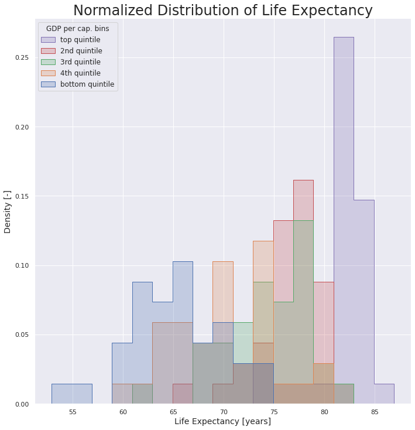

```python
data = df.query(f'time == 2019').dropna(subset=['life_expectancy'])

# create distribution plot based on last year available
data['GDP_binned'] = pd.qcut(data['GDP_per_cap'],q=5)

# get the bins and counts:
bins = pd.qcut(data['GDP_per_cap'],q=5).value_counts()

# limit number of columns:
datasubset = data[['life_expectancy','GDP_binned']]

fig = sns.displot(datasubset, height = 10,
            x = 'life_expectancy',
            hue = 'GDP_binned',
            binwidth=2,
            stat = 'density',
            element = 'step',
            common_norm = False,
            legend = False,
            );

# legend entries
legend_list = ('top quintile', '2nd quintile', '3rd quintile','4th quintile','bottom quintile')

plt.legend(title = 'GDP per cap. bins', loc = 'upper left',
          labels = legend_list,
          fontsize = 12);

plt.title('Normalized Distribution of Life Expectancy',
          fontsize = 24);

plt.xlabel('Life Expectancy [years]',fontsize = 14);
plt.ylabel('Density [-]',fontsize = 14);
```

```python
display(bins.to_frame())
```

|  | GDP_per_cap |
| --- | --- |
| (208.07399999999998, 1404.362] | 34 |
| (1404.362, 4094.59] | 34 |
| (4094.59, 8737.786] | 34 |
| (8737.786, 24137.472] | 34 |
| (24137.472, 111062.341] | 34 |

The distribution plot above show that the top 20% of countries by GDP per capita are also the countries with the highest life expectancy, the other quintiles follow in order of GDP per capita. Note that the bin size for the lowest group is only roughly 1200 dollars, whereas the top 20% encompasses GDP per capita from roughly \$24.000 to over \\$100.000.

#### Number of Children per Woman

```python
year_slider = widgets.IntSlider(min = 1960, max = 2019, step = 1,value = 1960, description = 'Year')

xr = (.1, 200)
yr = (0,10)
interact(splot, dframe=fixed(df),
         year = year_slider,
         indicator = fixed('children_per_woman'),
         ind_label = fixed('Number of Children per Woman'),
         region = fixed('geo6_name'),
         logx = fixed(True),
         logy = fixed(False),
         xrange = fixed(xr),
         yrange = fixed(yr));

interact(top_and_bottom, dframe = fixed(df),
        year = year_slider,
        indicator = fixed('children_per_woman'),
        ind_label = fixed('Number of Children per Woman'));
```

#### Child Deaths Under Five Years of Age

The dataset for this indicator only contains data for the year 2008, so trends over time cannot be shown, however, the information for the year 2008 is relatively complete with info on 178 countries:

```python
print('Unique years: ',df_deaths_under_5.time.unique())
print('Number of unique countries: ',df_deaths_under_5.geo.nunique())
```

```
Unique years:  [2008]
Number of unique countries:  178
```

```python
year_slider = widgets.IntSlider(min = 2008, max = 2008, step = 1,value = 2008, description = 'Year')

xr = (.2, 130)
yr = ()
interact(splot, dframe=fixed(df),
         year = year_slider,
         indicator = fixed('child_deaths'),
         ind_label = fixed('Number of Child Deaths under 5 Years of Age'),
         region = fixed('geo6_name'),
         logx = fixed(True),
         logy = fixed(True),
         xrange = fixed(xr),
         yrange = fixed(yr));

interact(top_and_bottom, dframe = fixed(df),
        year = year_slider,
        indicator = fixed('child_deaths'),
        ind_label = fixed('Number of Child Deaths under 5 Years of Age'));
```

#### Percentage of Girls Completing Primary School

Per Gapminder, this dataset contains some data limitations:

> Primary completion rate, or gross intake ratio to the last grade of primary education, is the number of new entrants (enrollments minus repeaters) in the last grade of primary education, regardless of age, divided by the population at the entrance age for the last grade of primary education. Data limitations preclude adjusting for students who drop out during the final year of primary education.

These limitations have as a result that for some countries and years, the completion rate is larger than 100 percent.

Additionally, this data is also only available from 1970 and on as shown below:

```python
# find the years for which we have data, so we can setup the slider
# if data is consecutive, if not either empyt years need to be accepted
# or widget needs to be swapped to drop down

years_with_data = df.query('girl_school_completion.isnull() == False',engine = 'python').time.unique()

print(np.sort(years_with_data))
```

```
[1970 1971 1972 1973 1974 1975 1976 1977 1978 1979 1980 1981 1982 1983
 1984 1985 1986 1987 1988 1989 1990 1991 1992 1993 1994 1995 1996 1997
 1998 1999 2000 2001 2002 2003 2004 2005 2006 2007 2008 2009 2010 2011
 2012 2013 2014 2015 2016 2017 2018 2019]
```

```python
year_slider = widgets.IntSlider(min = 1970, max = 2019, step = 1,value = 1970, description = 'Year')

xr = (.1, 200)
yr = (0, 120)
interact(splot, dframe=fixed(df),
         year = year_slider,
         indicator = fixed('girl_school_completion'),
         ind_label = fixed('Percentage of Girls Completing Elementary School'),
         region = fixed('geo6_name'),
         logx = fixed(True),
         logy = fixed(False),
         xrange = fixed(xr),
         yrange = fixed(yr));

interact(top_and_bottom, dframe = fixed(df),
        year = year_slider,
        indicator = fixed('girl_school_completion'),
        ind_label = fixed('Percentage of Girls Completing Elementary School'));
```

#### Percentage of Malnutrition in Children under Five Years of Age

```python
# find the years for which we have data, so we can setup the slider
# if data is consecutive, if not either empyt years need to be accepted
# or widget needs to be swapped to drop down

years_with_data = df.query('child_malnutrition.isnull() == False',engine = 'python').time.unique()

print(np.sort(years_with_data))
```

```
[1983 1985 1986 1987 1988 1989 1990 1991 1992 1993 1994 1995 1996 1997
 1998 1999 2000 2001 2002 2003 2004 2005 2006 2007 2008 2009 2010 2011
 2012 2013 2014 2015 2016 2017 2018 2019]
```

```python
year_slider = widgets.IntSlider(min = 1983, max = 2019, step = 1,value = 1983, description = 'Year')

xr = (.1, 200)
yr = (0, 50)
interact(splot, dframe=fixed(df),
         year = year_slider,
         indicator = fixed('child_malnutrition'),
         ind_label = fixed('Percentage of Malnutrition in Children under Five Years of Age'),
         region = fixed('geo6_name'),
         logx = fixed(True),
         logy = fixed(False),
         xrange = fixed(xr),
         yrange = fixed(yr));

interact(top_and_bottom, dframe = fixed(df),
        year = year_slider,
        indicator = fixed('child_malnutrition'),
        ind_label = fixed('Percentage of Malnutrition in Children under Five Years of Age'));
```

The number of datapoints available for child malnutrition are not enough to draw strong conclusions. For most years there are not enough datapoints to visualize a trend line.

## Conclusions

Across most of the selected indicators there is a strong correlation present between each indicator and GDP per capita. Some indicators show signs of reaching limits, such as a lower limit for number of children per woman after a certain GDP has been reached. Another example of this is school completion of girls. In the latter case this is a physical limit: there is no possibility of more than 100% school completion levels (excluding gaps in the data). For the limit on children per woman, the answer is likely culturally based: most cultures place a strong value on family life. Additional research would be necessary to confirm this.

Another effect of these limits is that it makes the correlation for poorer regions stronger, since less countries are near or over the limit. An example of this is visible in the 2019 plot of number of babies per woman by GDP. Sub-Saharan Africa shows a decent correlation, but Europe and Central Asia is mostly independent of GDP.

From the performed analysis it cannot be inferred whether or not correlation also means causation. Additional research would have to be performed to establish this.

It is however likely to assume that GDP growth has a positive impact on quality of life: in general a higher economic output for a country would mean more means to support its population. There are of course various factors that influence this, such as wealth gaps and democracy levels.

One has to be careful though in reaching conclusions by world region level: as the section on GPD growth showed, most regions have a small number of countries that dominate the numbers for the whole region. Examples of this are the United States and India.

Overal, there is however an undeniable trend visible that matches the conclusion reached by Dr. Hans Rosling in his book *Factfulness*, over time, all idicators move in the positive direction. There is however still a lot of catching up to do, especially in the Sub-Saharan region of Africa. In most cases, throughout the years, this region is last in class.

There are also strong signs of wealth gaps visible, for example in the bin distribution used in the *Life Expectancy* section. If the 2019 GDP per capita data would be binned using equal bin size using `cut()` instead of equal number of observations per bin (using `qcut()`), it becomes clear that the higher GDP per capita countries are highly concentrated. The result of this is shown below. The top 2 quintiles only consist of four countries wheras the bottom quintile consists of 139 countries.

```python
data = df[['time','GDP_per_cap']].query('time == 2019')
data['GDP_binned'] = pd.cut(data['GDP_per_cap'],bins=5)

# get the bins and counts:
bins = pd.cut(data['GDP_per_cap'],bins=5).value_counts()

display(bins.to_frame())
```

|  | GDP_per_cap |
| --- | --- |
| (97.22, 22378.928] | 139 |
| (22378.928, 44549.781] | 19 |
| (44549.781, 66720.634] | 16 |
| (66720.634, 88891.488] | 2 |
| (88891.488, 111062.341] | 2 |

```python
from subprocess import call
call(['python', '-m', 'nbconvert', 'Investigate_a_Dataset_Erik_de_Vries.ipynb'])
```

```
1
```